# DeepPAM Basics

Lukas

2021-06-01 19:33:27

```r
knitr::opts_chunk$set(
  message=FALSE, error=TRUE, warning=FALSE
)

# Modeling
library(keras)
library(mgcv)

# Convenience
library(dplyr)
library(broom)
library(ggplot2)

# Sacrificing a goat to the python env
reticulate::use_condaenv("r-reticulate", required = TRUE)
reticulate:::ensure_python_initialized()
tensorflow::tf_config()
```

```
## TensorFlow v2.1.0 (~/Library/r-miniconda/envs/r-reticulate/lib/python3.6/site-packages/tensorflow)
## Python v3.6 (~/Library/r-miniconda/envs/r-reticulate/bin/python)
```

# 1 Linear Models

```r
set.seed(17)
n <- 700
x1 <- runif(n, 0, 10)
x2 <- runif(n, -2, 2)
x3 <- sample(c(0, 1), n, replace = TRUE)

y <- 1 + 2 * x1 + 3 * x2 + 4 * x3 + rnorm(n, 0, 1)
df <- data.frame(y, x1, x2, x3)
```

## 1.1 `lm()`

```r
lm_lm <- lm(y ~ x1 + x2 + x3, data = df)

tidy(lm_lm)
```

```
## # A tibble: 4 x 5
##   term        estimate std.error statistic   p.value
##   <chr>          <dbl>     <dbl>     <dbl>     <dbl>
## 1 (Intercept)     1.02    0.0894      11.5 5.41e- 28
## 2 x1              2.00    0.0136     147.  0
## 3 x2              3.01    0.0333      90.1 0
## 4 x3              3.96    0.0786      50.3 3.22e-234
```

```r
glance(lm_lm)
```

```
## # A tibble: 1 x 12
##   r.squared adj.r.squared sigma statistic p.value    df logLik   AIC   BIC
##       <dbl>         <dbl> <dbl>     <dbl>   <dbl> <dbl>  <dbl> <dbl> <dbl>
## 1     0.978         0.978  1.04    10456.       0     3 -1018. 2045. 2068.
## # … with 3 more variables: deviance <dbl>, df.residual <int>, nobs <int>
```

## 1.2 `keras`

- Single layer NN
- Linear regression layer with bias

```r
lm_nn <- keras_model_sequential(name = "LM") %>%
  layer_dense(units = 1, activation = "linear", use_bias = TRUE, name = "Regression")

lm_nn %>%
  compile(
    loss = "mse",
    optimizer = optimizer_rmsprop(),
    metrics = NULL
  )

lm_nn %>%
  fit(
    as.matrix(df[, 2:4]), df$y,
    epochs = 100,
    batch_size = 8,
    validation_split = 0.2,
    verbose = TRUE
  )

lm_nn
```

```
## Model
## Model: "LM"
## ________________________________________________________________________________
## Layer (type)                        Output Shape                    Param #
## ================================================================================
## Regression (Dense)                  multiple                        4
## ================================================================================
## Total params: 4
## Trainable params: 4
## Non-trainable params: 0
## ________________________________________________________________________________
```

```r
get_weights(lm_nn)
```

```
## [[1]]
##          [,1]
## [1,] 1.981776
## [2,] 3.023085
## [3,] 3.789641
##
## [[2]]
## [1] 1.234797
```

Close enough?

# 2 Generalised Additive Models

```r
set.seed(17)
n <- 700
x1 <- runif(n, 0, 10)
x2 <- runif(n, -2, 2)
x3 <- sample(c(0, 1), n, replace = TRUE)

predictor <- -3 + 0.05 * x1^2 + x2 + x3
prob <- exp(predictor) / (1 + exp(predictor))
y <- rbinom(n, 1, prob)
df <- data.frame(y, x1, x2, x3)
```

## 2.1 `mgcv()`

> Use the mgcv package to estimate a GAM with linear effects of x2 and x3 and a smooth x1 effect.

```r
gam_mgcv <- gam(y ~ s(x1, fx = FALSE) + x2 + x3, family = binomial(link = "logit"), data = df)

gam_mgcv$coefficients
```

```
##  (Intercept)           x2           x3      s(x1).1      s(x1).2      s(x1).3
## -1.403222857  1.150180559  1.185939615  0.002580073 -0.211213984  0.047243729
##      s(x1).4      s(x1).5      s(x1).6      s(x1).7      s(x1).8      s(x1).9
## -0.165042227  0.056723938 -0.185237557  0.033842307 -0.910089541  1.431656046
```

```r
# smoothing param for later
gam_mgcv$sp
```

```
##    s(x1)
## 1.397658
```

```r
# S matrix
gam_mgcv$smooth[[1]]$S
```

```
## [[1]]
##                [,1]          [,2]          [,3]          [,4]          [,5]
##  [1,]  6.827540e+00 -9.348319e-01 -3.542959e+00  1.065734e+00 -4.579464e+00
##  [2,] -9.348319e-01  1.220239e+01  5.628796e-01 -6.293468e+00  4.042009e+00
##  [3,] -3.542959e+00  5.628796e-01  5.319356e+01  2.386721e+00 -5.101339e+00
##  [4,]  1.065734e+00 -6.293468e+00  2.386721e+00  5.292410e+01  6.499267e+00
##  [5,] -4.579464e+00  4.042009e+00 -5.101339e+00  6.499267e+00  1.214082e+02
##  [6,]  3.732978e+00 -1.349754e+01  4.730126e+00 -1.916964e+01  9.612156e+00
##  [7,] -5.340484e+00  4.699940e+00 -5.482847e+00  6.069105e+00 -6.533921e+00
##  [8,] -1.219789e+00  4.511026e-01  7.640241e-01 -6.278076e+00  5.199792e+00
##  [9,]  9.773332e-17 -3.614376e-17 -6.121603e-17  5.030193e-16 -4.166238e-16
##                [,6]          [,7]          [,8]          [,9]
##  [1,]  3.732978e+00 -5.340484e+00 -1.219789e+00  9.773332e-17
##  [2,] -1.349754e+01  4.699940e+00  4.511026e-01 -3.614376e-17
##  [3,]  4.730126e+00 -5.482847e+00  7.640241e-01 -6.121603e-17
##  [4,] -1.916964e+01  6.069105e+00 -6.278076e+00  5.030193e-16
##  [5,]  9.612156e+00 -6.533921e+00  5.199792e+00 -4.166238e-16
##  [6,]  1.092277e+02  7.561453e+00 -1.597419e+01  1.279903e-15
##  [7,]  7.561453e+00  3.089331e+02  6.609221e+00 -5.295517e-16
##  [8,] -1.597419e+01  6.609221e+00  7.665869e+00 -6.142137e-16
##  [9,]  1.279903e-15 -5.295517e-16 -6.142137e-16  4.921274e-32
```

Takeaway: I need to do some GAM-reading.

## 2.2 `keras`

> Neglect the penalisation of the smooth eﬀect and construct an equivalent neural network with keras and tensorflow. Fit it.
- Two parallel layers for linear / smooth effects? 🤔
- [Relevant Keras docs maybe](https://keras.rstudio.com/articles/functional_api.html)

```r
# Define inputs, two linear + 1 smooth effect
linear_input <- layer_input(shape = c(2), name = "linear_in")
smooth_input <- layer_input(shape = c(1), name = "smooth_in")

# Define intermediate outputs
linear_out <- linear_input %>%
  layer_dense(units = 1, activation = "linear", name = "linear_effect")

# Until I figure out what to use for a smooth effect here
# mgcv shows 9 components of the smooth effects, but just 1 neuron though
smooth_out <- smooth_input %>%
  layer_dense(units = 1, activation = "linear", name = "smooth_effect")

# layer_concatenate sums up intermediate outputs
# sigmoid activation for binary outcome
combined_out <- layer_concatenate(c(linear_out, smooth_out)) %>%
  #layer_lambda(f = function(x) k_sum(x, axis = 2)) %>%
  layer_dense(units = 1, activation = "sigmoid", name = "output_prob")

# Combine the above to a keras model
gam_nn <- keras_model(
  inputs = c(linear_input, smooth_input),
  outputs = c(combined_out)
)

gam_nn %>%
  compile(
    loss = "binary_crossentropy", # That's Bernoulli logLik right?
    optimizer = optimizer_rmsprop(),
    metrics = NULL
  )

gam_nn
```

```
## Model
## Model: "model"
## ________________________________________________________________________________
## Layer (type)              Output Shape      Param #  Connected to
## ================================================================================
## linear_in (InputLayer)    [(None, 2)]       0
## ________________________________________________________________________________
## smooth_in (InputLayer)    [(None, 1)]       0
## ________________________________________________________________________________
## linear_effect (Dense)     (None, 1)         3        linear_in[0][0]
## ________________________________________________________________________________
## smooth_effect (Dense)     (None, 1)         2        smooth_in[0][0]
## ________________________________________________________________________________
## concatenate (Concatenate) (None, 2)         0        linear_effect[0][0]
##                                                      smooth_effect[0][0]
## ________________________________________________________________________________
## output_prob (Dense)       (None, 1)         3        concatenate[0][0]
## ================================================================================
## Total params: 8
## Trainable params: 8
## Non-trainable params: 0
## ________________________________________________________________________________
```

```r
gam_nn %>%
  fit(
    # First linear input (x2, x3), then smooth input (x1)
    x = list(as.matrix(df[, 3:4]), as.matrix(df[, 2])),
    y = df$y,
    epochs = 50,
    batch_size = 8,
    validation_split = 0.2,
    verbose = TRUE
  )

get_weights(gam_nn)
```

```
## [[1]]
##            [,1]
## [1,] -0.6321335
## [2,] -0.4327444
##
## [[2]]
## [1] 0.7962032
##
## [[3]]
##           [,1]
## [1,] 0.7526769
##
## [[4]]
## [1] -0.2411727
##
## [[5]]
##            [,1]
## [1,] -1.4852345
## [2,]  0.3413815
##
## [[6]]
## [1] -0.7952259
```

Smells overparameterized?

## 2.3 Plot comparion

> Use the plot function to plot the mgcv model’s smooth term.

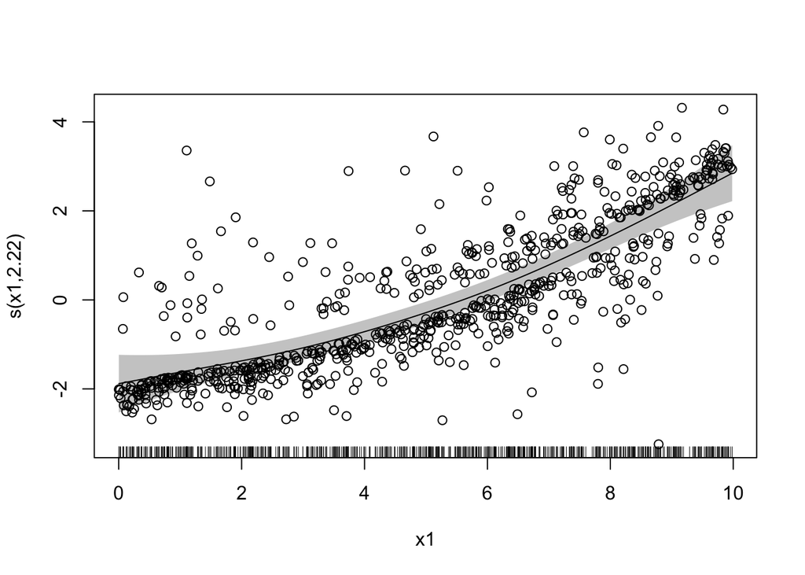

```r
plot(gam_mgcv, select = 1, resid = TRUE, pch = 1, cex = 1, shade = TRUE)
```

## 2.4 `keras` w/ Penalisation

> Read [here](https://m-clark.github.io/generalized-additive-models/technical.html) about the penalisation of smooth terms in mgcv. Search through the mgcv model for all components of the penalisation.

> Apply the proper penalisation to the equivalent neural network and refitt the network. Compare the resulting smooth terms with meaningful plots (see 3)). Use the extracted components from 4) You will find the code below helpful.

```r
kernel_regularizer = function(x) {
  k_mean(k_batch_dot(x, k_dot(
  tf$constant(???, dtype = "float64"), x), axes = 2))
}
```

From Wood 2017:

$$||\boldsymbol{y} - \boldsymbol{X}\boldsymbol{\beta}||^2 + \underbrace{\lambda \boldsymbol{\beta}^\top \boldsymbol{S} \boldsymbol{\beta}}_\text{Regularization term to reconstruct}$$

Current regularizer form:

$$\begin{aligned}
\mathtt{mean(batch\_dot(x, dot(???, x))) } & \overset{?}{=}
\frac{1}{n} \sum \sum_{\mathrm{batch}} \boldsymbol{\beta} \cdot (??? \cdot \boldsymbol{\beta})
\end{aligned}$$

Making a D and S matrix

```r
make_Dmat <-function(k = 8) {
  diff(diag(k), differences = 2)
}
# S := D^T D
make_Smat <- function(k = 8) t(make_Dmat(k)) %*% make_Dmat(k)

# Or just take the one from mgcv as I'm presumably supposed to
# Also multiply with lambda for convenience
gam_Smat <- gam_mgcv$sp * gam_mgcv$smooth[[1]]$S[[1]]
```

```r
smooth_out_reg <- smooth_input %>%
  layer_dense(
    units = 1, activation = "linear", name = "smooth_effect",
    kernel_regularizer = function(x) {
      # with only one neuron the shapes don't fit though o_O
      k_mean(k_batch_dot(x,
        k_dot(
          tensorflow::tf$constant(gam_Smat, dtype = "float32"),
          x
        ),
      axes = 2
      ))
    }
  )

combined_out_reg <- layer_concatenate(c(linear_out, smooth_out_reg)) %>%
  #layer_lambda(f = function(x) k_sum(x, axis = 2)) %>%
  layer_dense(units = 1, activation = "sigmoid", name = "output_prob")

# Combine the above to a keras model
gam_nn_reg <- keras_model(
  inputs = c(linear_input, smooth_input),
  outputs = c(combined_out_reg)
)
```

Does it do things?

```r
gam_nn_reg %>%
  compile(
    loss = "binary_crossentropy", # That's Bernoulli logLik right?
    optimizer = optimizer_rmsprop(),
    metrics = NULL
  )
```

[output not shown]

```r
gam_nn_reg
```

```
## Model
## Model: "model_1"
## ________________________________________________________________________________
## Layer (type)              Output Shape      Param #  Connected to
## ================================================================================
## linear_in (InputLayer)    [(None, 2)]       0
## ________________________________________________________________________________
## smooth_in (InputLayer)    [(None, 1)]       0
## ________________________________________________________________________________
## linear_effect (Dense)     (None, 1)         3        linear_in[0][0]
## ________________________________________________________________________________
## smooth_effect (Dense)     (None, 1)         2        smooth_in[0][0]
## ________________________________________________________________________________
## concatenate_1 (Concatenat (None, 2)         0        linear_effect[0][0]
##                                                      smooth_effect[0][0]
## ________________________________________________________________________________
## output_prob (Dense)       (None, 1)         3        concatenate_1[0][0]
## ================================================================================
## Total params: 8
## Trainable params: 8
## Non-trainable params: 0
## ________________________________________________________________________________
```

```r
gam_nn_reg %>%
  fit(
    # First linear input (x2, x3), then smooth input (x1)
    x = list(as.matrix(df[, 3:4]), as.matrix(df[, 2])),
    y = df$y,
    epochs = 20,
    batch_size = 8,
    validation_split = 0.2,
    verbose = TRUE
  )
```

[output not shown]

[output cut: 25 more lines]

[output not shown]

What do the predictions look like?

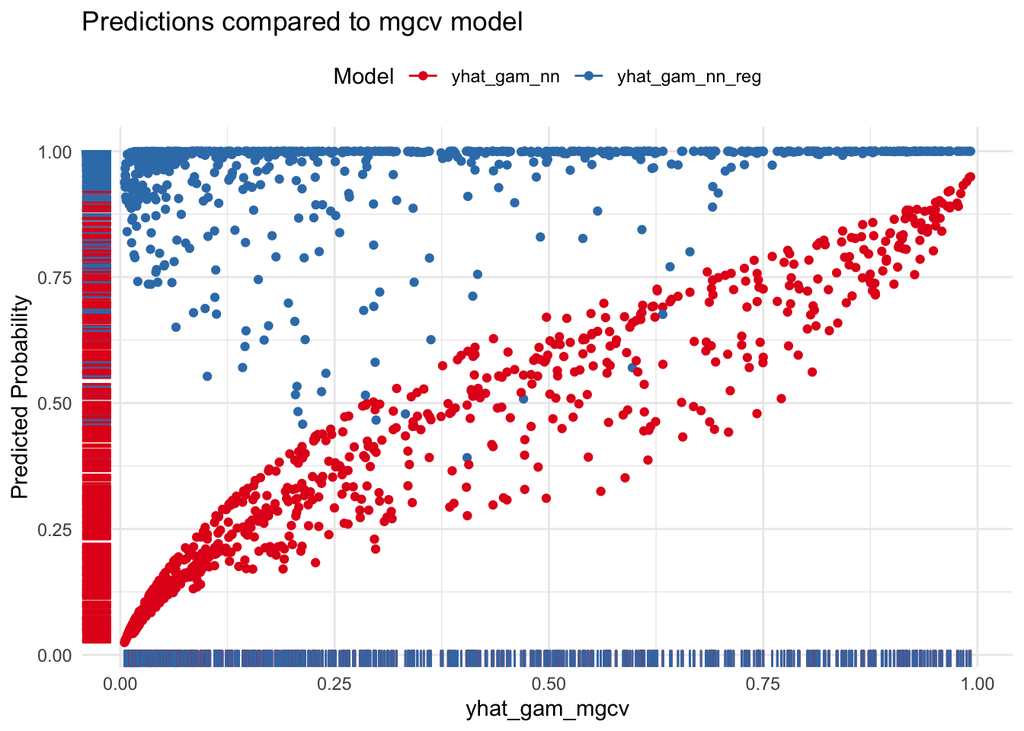

```r
yhat_gam_mgcv <- predict(gam_mgcv, newdata = df, type = "link")
yhat_gam_mgcv <- exp(yhat_gam_mgcv) / (1 + exp(yhat_gam_mgcv))
yhat_gam_nn <- predict(gam_nn, x = list(as.matrix(df[, 3:4]), as.matrix(df[, 2])))
yhat_gam_nn_reg <- predict(gam_nn_reg, x = list(as.matrix(df[, 3:4]), as.matrix(df[, 2])))

yhat_df <- tibble(
  y = df$y,
  yhat_gam_mgcv = yhat_gam_mgcv,
  yhat_gam_nn = as.numeric(yhat_gam_nn),
  yhat_gam_nn_reg = as.numeric(yhat_gam_nn_reg)
)

# yhat_df %>%
#   ggplot(aes(x = yhat_gam_nn, y = yhat_gam_nn_reg)) +
#   geom_point(shape = 21)
#
# yhat_df %>%
#   ggplot(aes(x = yhat_gam_mgcv, y = yhat_gam_nn_reg)) +
#   geom_point(shape = 21)

yhat_df %>%
  tidyr::pivot_longer(cols = contains("_nn")) %>%
  ggplot(aes(x = yhat_gam_mgcv, y = value, fill = name, color = name)) +
  geom_point(shape = 21) +
  geom_rug() +
  scale_color_brewer(palette = "Set1", aesthetics = c("color", "fill")) +
  labs(
    title = "Predictions compared to mgcv model",
    y = "Predicted Probability",
    color = "Model", fill = "Model"
  ) +
  theme_minimal() +
  theme(legend.position = "top")
```

I can’t tell if that’s good or bad 🙃